# Compressing a kernel density estimate into a mixture

```r
library(proxymix)
```

```r
has_ggplot2 <- requireNamespace("ggplot2", quietly = TRUE)
```

## The problem

A kernel density estimate turns a sample into a smooth density without assuming a shape for it. It places a small normal bell curve, called a kernel, on every data point and averages them. The width of the kernels is called the bandwidth. A narrow bandwidth keeps every bump in the sample, and a wide one smooths them away.

The estimate from 300 data points is therefore a mixture of 300 normal distributions. Both its density at a point and the distribution of one variable when another is held at a fixed value involve all 300 of them. The work grows with the size of the sample. This matters when an analysis repeats such steps many times.

proxymix replaces the estimate with a mixture of a few normal distributions, for example two or five, chosen to be as close to the estimate as possible. This smaller mixture is called the proxy. The same steps on the proxy involve only its few components.

This vignette compresses the estimate of a sample from two groups, measures what the compression loses, and compares the result with five other R packages.

## Package capabilities

- `from_kde()` builds the kernel density estimate from a data matrix and compresses it into an `N`-component Gaussian mixture, a sum of `N` normal distributions. Its `bandwidth` argument takes a rule by name or numbers, a single number for all variables or one number per variable. The default, `"plugin"`, is the Sheather-Jones plug-in bandwidth of each variable (Sheather and Jones, 1991). The rules of thumb `"silverman"` and `"scott"` (Silverman, 1986, and Scott, 1992) smooth more.
- `from_kde()` fits the proxy with the package’s method for a density that can be evaluated but not sampled (van der Hoek and Elliott, 2024), described in *Fitting a proxy to a density you cannot sample*. It draws `is_size` trial points from a simple wide distribution and weights each by how likely it is under the estimate, `10000 + 2500 * N` points by default. It also draws fresh points that are not used in the fit. By default it adds them in batches of `is_size` until the KL estimate is precise, up to `10 * is_size` points.
- `ess_summary()` reports the quality of the weighted draws and the Kullback-Leibler (KL) divergence between the proxy and the estimate, measured on the fresh draws (`validation_kld`). The KL divergence is zero when two densities match and grows as they differ.
- `hellinger_mc()` estimates a second distance between the proxy and the estimate, the squared Hellinger distance, from fresh random draws. It lies between 0, for identical densities, and 1.
- `dgmm()`, `rgmm()`, `gmm_marginalise()` and `gmm_conditionalise()` give density values, random draws, the distribution of one variable on its own, and the distribution of one variable when another is held fixed. `gmm_affine()` gives the distribution of a linear transformation of the variables, and `gmm_observe()` updates the proxy after a measurement with normal noise.

## Addressing the problem

### A sample from two groups

The data are simulated, so the true density is known. Half of the 300 points come from a normal distribution centred at $(-2, 0)$ and half from one centred at $(2, 0)$, both with unit variances and no correlation. The call fits a proxy with two components and uses Silverman’s rule for the bandwidth. It sets `is_size` and `validation_size` below their defaults to keep the vignette fast.

```r
set.seed(20260601)

n_each <- 150L
true_means <- cbind(c(-2, 0), c(2, 0))
true_cov <- diag(2)
x <- rbind(
  mvnfast::rmvn(n_each, mu = true_means[, 1L], sigma = true_cov),
  mvnfast::rmvn(n_each, mu = true_means[, 2L], sigma = true_cov)
)

fit <- from_kde(
  x, N = 2L,
  bandwidth = "silverman",
  is_size = 2000L, max_iter = 60L, seed = 1L,
  validation_size = 2000L
)
fit
```

```
#> <gmm_fit>: regime = "kld", K = 2, p = 2
#>   target     : from_kde
#>   iterations : 10
#>   converged  : TRUE
#>   [1] w = 0.5225, |mu| = 2.0526, tr(Sigma) = 2.7785
#>   [2] w = 0.4775, |mu| = 1.9564, tr(Sigma) = 2.6586
```

### The recovered groups

Sorting the two fitted components by their first coordinate puts them in the same order as the true groups.

```r
mu_hat <- vapply(fit@means, function(mu) mu, numeric(2L))
comp_order <- order(mu_hat[1L, ])
mu_hat <- mu_hat[, comp_order, drop = FALSE]
weight_hat <- fit@weights[comp_order]
mean_error <- max(abs(mu_hat - true_means))
```

The means and weights of the two fitted components beside the means of the two groups the 300 points were drawn from.

| Component | Fitted $x_1$ | Fitted $x_2$ | True $x_1$ | True $x_2$ | Weight |
| --- | --- | --- | --- | --- | --- |
| 1 | -1.954 | 0.105 | -2 | 0 | 0.478 |
| 2 | 2.046 | -0.159 | 2 | 0 | 0.522 |

### Check the fit

The effective sample size is the number of equally weighted draws that the weighted draws are worth. It should be close to the number of draws, and no single draw should carry much of the weight. The KL divergence is reported on the fresh draws, with its Monte Carlo standard error, the random error due to the finite number of draws. The KL divergence on the draws used for fitting reads too low, because the fit was tuned to those draws.

```r
es <- ess_summary(fit)
print(data.frame(is_size = es$is_size, ess = round(es$ess, 1),
                 ess_relative = round(es$ess_relative, 3),
                 max_weight = signif(es$max_weight, 3)),
      row.names = FALSE)
```

```
#>  is_size  ess ess_relative max_weight
#>     2000 1538        0.769    0.00116
```

```r
print(data.frame(validation_size = es$validation_size,
                 validation_kld = signif(es$validation_kld, 3),
                 validation_se = signif(fit@diagnostics$validation_mc_se, 3)),
      row.names = FALSE)
```

```
#>  validation_size validation_kld validation_se
#>             2000          0.016       0.00449
```

### What the compression loses

The proxy and the kernel estimate are both densities on the same plane, so the gap between them can be added up on a fine grid. The total variation distance is half the total absolute gap. It is the largest difference between the probabilities that the two densities give to any region. The squared Hellinger distance comes from 10,000 fresh draws from the proxy.

```r
g1 <- seq(-6, 6, length.out = 160L)
g2 <- seq(-5, 5, length.out = 140L)
grid <- expand.grid(x1 = g1, x2 = g2)
gm <- as.matrix(grid)
cell <- (g1[2L] - g1[1L]) * (g2[2L] - g2[1L])

grid$kde <- exp(fit@target@log_density(gm))
grid$proxy <- dgmm(gm, fit)

total_variation <- 0.5 * sum(abs(grid$kde - grid$proxy)) * cell
hell <- hellinger_mc(fit, n_mc = 10000L, seed = 1L)
c(total_variation = signif(total_variation, 3),
  hellinger_sq = signif(hell$h2, 3), hellinger_se = signif(hell$se, 3))
```

```
#> total_variation    hellinger_sq    hellinger_se
#>         0.06250         0.00373         0.00090
```

The figure shows where the two densities differ. Both are drawn on the log scale with the same contour levels.

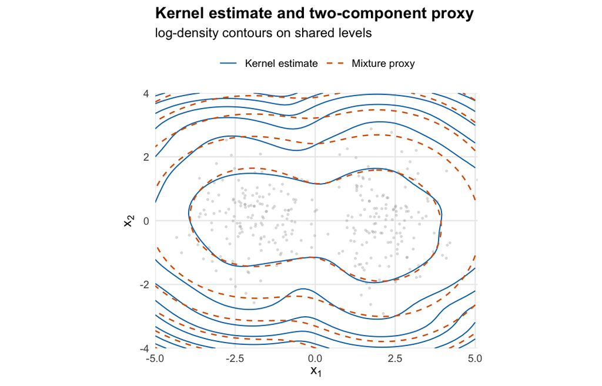

Contours of the log-density of the kernel estimate (blue, solid) and of the two-component proxy (orange, dashed), on shared levels, over the 300 data points (grey). Around the two group centres the contours nearly coincide. On the outer, low-density levels the kernel estimate bends around single outlying points, and the proxy stays smooth.

```r
plot_grid <- expand.grid(
  x1 = seq(-5, 5, length.out = 80L),
  x2 = seq(-4, 4, length.out = 60L)
)
pm <- as.matrix(plot_grid)
plot_grid$kde <- fit@target@log_density(pm)
plot_grid$proxy <- log(dgmm(pm, fit))

## Shared contour levels so the two log-densities are directly comparable.
brks <- pretty(range(c(plot_grid$kde, plot_grid$proxy), finite = TRUE), 9L)
sample_df <- data.frame(x1 = x[, 1L], x2 = x[, 2L])

ggplot2::ggplot() +
  ggplot2::geom_point(data = sample_df, ggplot2::aes(x1, x2),
                      colour = "grey60", alpha = 0.25, size = 0.5) +
  ggplot2::geom_contour(
    data = plot_grid,
    ggplot2::aes(x1, x2, z = kde, colour = "Kernel estimate",
                 linetype = "Kernel estimate"),
    breaks = brks, linewidth = 0.45
  ) +
  ggplot2::geom_contour(
    data = plot_grid,
    ggplot2::aes(x1, x2, z = proxy, colour = "Mixture proxy",
                 linetype = "Mixture proxy"),
    breaks = brks, linewidth = 0.55
  ) +
  ggplot2::scale_colour_manual(
    name = NULL,
    values = c("Kernel estimate" = "#0072B2", "Mixture proxy" = "#D55E00")
  ) +
  ggplot2::scale_linetype_manual(
    name = NULL,
    values = c("Kernel estimate" = "solid", "Mixture proxy" = "dashed")
  ) +
  ggplot2::coord_equal(expand = FALSE) +
  ggplot2::labs(
    title = "Kernel estimate and two-component proxy",
    subtitle = "log-density contours on shared levels",
    x = expression(x[1]), y = expression(x[2])
  ) +
  ggplot2::theme_minimal(base_size = 11) +
  ggplot2::theme(plot.title = ggplot2::element_text(face = "bold"),
                 legend.position = "top",
                 panel.grid.minor = ggplot2::element_blank())
```

### Use the proxy

`gmm_conditionalise(given = c(NA, 0))` gives the distribution of $x_1$ when $x_2$ equals 0, with `NA` marking the variable left free. The result is a mixture with the proxy’s two components, and `rgmm()` draws from it in one call.

```r
slice <- gmm_conditionalise(fit, given = c(NA, 0))
draws <- rgmm(200L, slice)
c(components = gmm_n_components(slice), dimension = gmm_dim(slice),
  draws = nrow(draws))
```

```
#> components  dimension      draws
#>          2          1        200
```

### The effect of the bandwidth

The proxy has the same smoothing as the estimate it compresses. The code below compresses the same sample with three bandwidths, at 1,500 weighted draws. By default the fresh draws are added in batches until the standard error of the KL divergence is at most a tenth of the estimate, or at most 0.001 when the estimate is below 0.01, up to ten times `is_size` draws.

```r
bandwidth_grid <- c(0.2, 0.5, 1.0)
fits <- lapply(bandwidth_grid, function(h) {
  from_kde(x, N = 2L, bandwidth = h,
           is_size = 1500L, max_iter = 40L, seed = 1L)
})
sweep_is <- fits[[1L]]@diagnostics$is_size
sweep_vs <- vapply(fits, function(f) f@diagnostics$validation_size,
                   numeric(1L))
sweep_val <- vapply(fits, function(f) f@diagnostics$validation_kld,
                    numeric(1L))
sweep_se <- vapply(fits, function(f) f@diagnostics$validation_mc_se,
                   numeric(1L))
```

The same sample compressed with three bandwidths, at 1500 weighted draws. The spread of the left-hand component is the sum of its two variances.

| Bandwidth | Effective sample size | Largest weight | Spread of left component | Fresh draws | KL, fresh draws | Standard error |
| --- | --- | --- | --- | --- | --- | --- |
| 0.2 | 791.4 | 0.00313 | 1.675 | 3000 | 0.20 | 0.017 |
| 0.5 | 1019.0 | 0.00172 | 2.077 | 9000 | 0.030 | 0.0028 |
| 1.0 | 1205.3 | 0.00124 | 3.443 | 10500 | 0.0061 | 0.00098 |

### Comparison with ks, np, KernSmooth, mclust and mixtools

In a simulation, `from_kde()` was compared with three kernel estimators and two packages that fit a Gaussian mixture directly to the data. ks (Duong, 2007) computed the kernel estimate with a bandwidth set from the data by a formula, its plug-in rule. `from_kde()` compressed that same estimate at 3, 5 and 8 components. KernSmooth (Wand and Jones, 1995) computed the same estimate on a grid by binning the data, and np (Hayfield and Racine, 2008) chose its own bandwidths by cross-validation. mclust (Scrucca et al., 2016) chose its number of components by the Bayesian information criterion (BIC), a score that trades fit against the number of parameters. mixtools (Benaglia et al., 2009) was given the true number, three. Each method estimated the density of 100 datasets of 500 points, drawn from a known mixture of three normal distributions in two dimensions. The measure is the integrated squared error: the squared gap between the estimated and the true density, added up over the plane. Smaller is better, and zero is a perfect estimate.

Integrated squared error against the true density, in thousandths, averaged over 100 simulated datasets of 500 points, with its standard error in brackets. The difference from ks is taken dataset by dataset. A negative value means a smaller error than ks. Seconds per fit is the mean time to fit one dataset.

| Method | Error | Difference from ks | Seconds per fit |
| --- | --- | --- | --- |
| ks | 1.689 (0.042) |  | 0.121 |
| KernSmooth | 1.689 (0.042) | -0.0004 (0.0002) | 0.008 |
| np | 1.666 (0.042) | -0.0227 (0.0089) | 0.165 |
| proxymix, 3 components | 1.315 (0.037) | -0.3742 (0.0209) | 0.587 |
| proxymix, 5 components | 1.525 (0.040) | -0.1637 (0.0190) | 0.741 |
| proxymix, 8 components | 1.692 (0.046) | 0.0028 (0.0163) | 0.931 |
| mclust, components by BIC | 0.969 (0.043) | -0.7197 (0.0468) | 0.392 |
| mixtools, 3 components | 0.776 (0.108) | -0.9127 (0.1164) | 5.612 |

At 3 and 5 components, the proxy had a smaller error than all three kernel estimators: 1.31 and 1.53 thousandths, against 1.67 to 1.69. A proxy with few components cannot follow the random bumps in the kernel estimate. Here that smoothing moved it closer to the truth. At 8 components the proxy was level with ks (difference 0.003, standard error 0.016) and slightly behind np. mclust and mixtools, which fit a mixture to the data directly, had the smallest errors of all, 0.97 and 0.78 thousandths. Unlike mclust, mixtools did not have to choose the number of components. The true density in this design is itself a mixture of three normal distributions, which favours every method that fits a mixture.

proxymix took 0.59 to 0.93 seconds per fit, slower than ks (0.12), np (0.17), KernSmooth (0.008) and mclust (0.39), and faster than mixtools (5.6). Query times were measured on the Old Faithful data (Azzalini and Bowman, 1990) and the Palmer penguins data (Gorman et al., 2014; Horst et al., 2022), as the median of five timings on one computer, averaged over the two datasets. A query here is the conditional mean and the 90% conditional quantile of one variable given the other. On the three-component proxy a query took 0.34 milliseconds (ms). That is about 34 times faster than the 11.6 ms for the ks estimate evaluated on a grid of 401 points, and about 17 times slower than the 0.020 ms for the KernSmooth grid. Queries on the mixtures from mclust and from mixtools, here with two components, took 0.34 and 0.28 ms, and queries on np took 1.30 ms.

The code below fits one simulated dataset with all six packages and computes the integrated squared error of each. It repeats the simulation code for a single dataset. It needs ks, np, mclust and mixtools from CRAN (KernSmooth ships with R), and it is not run when this vignette is built.

```r
library(proxymix)
library(mclust)
library(mixtools)
library(np)
options(np.messages = FALSE)

# one dataset of 500 points from a mixture of three normal distributions
truth <- list(
  weights = c(0.35, 0.35, 0.30),
  means = list(c(-2, 0), c(2, 1), c(0, 4)),
  covs = list(diag(2), matrix(c(1, 0.5, 0.5, 1), 2L), 0.6 * diag(2))
)
set.seed(1L)
n <- 500L
k <- sample.int(3L, n, replace = TRUE, prob = truth$weights)
x <- matrix(NA_real_, n, 2L)
for (j in seq_len(3L)) {
  s <- k == j
  x[s, ] <- mvnfast::rmvn(sum(s), truth$means[[j]], truth$covs[[j]])
}

# integrated squared error against the true density, on a grid
g1 <- seq(-6, 6, length.out = 121L)
g2 <- seq(-4, 8, length.out = 121L)
grid <- as.matrix(expand.grid(x1 = g1, x2 = g2))
cell <- (g1[2L] - g1[1L]) * (g2[2L] - g2[1L])
f_true <- Reduce(`+`, lapply(seq_len(3L), function(j) {
  truth$weights[j] * mvnfast::dmvn(grid, truth$means[[j]], truth$covs[[j]])
}))
ise <- function(f_hat) sum((f_hat - f_true)^2) * cell
as_gmm <- function(w, mu, sigma) {
  gmm(weights = w, means = mu, covariances = sigma)
}

# ks with its diagonal plug-in bandwidth, and proxymix compressing the same estimate
h <- sqrt(diag(ks::Hpi.diag(x)))
kd <- ks::kde(x, H = diag(h^2), eval.points = grid)
f <- from_kde(x, N = 3L, bandwidth = h, is_size = 20000L, seed = 1L)

mc <- Mclust(x, verbose = FALSE)
g_mc <- as_gmm(
  mc$parameters$pro,
  lapply(seq_len(mc$G), function(j) mc$parameters$mean[, j]),
  lapply(seq_len(mc$G), function(j) mc$parameters$variance$sigma[, , j])
)
mt <- mvnormalmixEM(x, k = 3L)
nd <- npudens(npudensbw(x))
f_np <- predict(nd, newdata = data.frame(grid))
bk <- KernSmooth::bkde2D(x, bandwidth = h, gridsize = c(121L, 121L),
                         range.x = list(range(g1), range(g2)))

1000 * c(ks = ise(kd$estimate),
         proxymix = ise(dgmm(grid, f)),
         mclust = ise(dgmm(grid, g_mc)),
         mixtools = ise(dgmm(grid, as_gmm(mt$lambda, mt$mu, mt$sigma))),
         np = ise(f_np),
         KernSmooth = ise(as.vector(bk$fhat)))
```

The [extended version of this article](https://max578.github.io/proxymix/articles/extended/from_kde.html) gives the full simulation and the conditional queries on the Old Faithful and Palmer penguins data.

## Interpretation

The proxy recovers the two groups the 300 points came from. Its means differ from the true means by at most 0.16, and its weights are 0.478 and 0.522, against 0.5 for each group.

The diagnostics of the weighted draws show no problem. The effective sample size was 1538 out of 2000, or 77 per cent, and the heaviest single draw held 0.0012 of the total weight. On 2000 fresh draws the KL divergence between the proxy and the kernel estimate was 0.016, with a standard error of 0.0045.

The total variation distance between the kernel estimate and the proxy is 0.062. The two densities therefore give any region probabilities that differ by at most about 6.2 percentage points. The squared Hellinger distance is 0.0037, with a standard error of 0.0009, about 4 standard errors above zero. The figure shows where the difference lies: in the outer, low-density region, where the kernel estimate follows single points. The gain is in size: the conditional distribution computed above has 2 components. The same conditional of the kernel estimate also has an exact formula, but it has 300 components.

The bandwidth affects the proxy as it affects the estimate. A wider bandwidth gives a smoother estimate that is easier to fit. The effective sample size rises from 791 at bandwidth 0.2 to 1205 at bandwidth 1.0, out of 1500 draws. The spread of the left-hand component grows from 1.67 to 3.44, because the proxy copies the extra smoothing. The KL divergence on fresh draws falls from 0.2 at bandwidth 0.2 to 0.03 at bandwidth 0.5. At the narrowest bandwidth the estimate keeps the bumps of the sample, which two components cannot follow. At bandwidth 1.0 the KL divergence on fresh draws is 0.0061, with a standard error of 0.001. It is small but above zero: two components do not reproduce even the smoothest of the three estimates exactly.

## Limitations

`from_kde()` is tested for up to five variables. It warns between six and ten and refuses more than ten. Weighted trial draws lose efficiency quickly as the number of variables grows. This vignette uses two. For more variables, fit a proxy in a few variables and extend it with `gmm_affine()` and the other exact operations instead.

The bandwidth must be one number or one number per variable. A full bandwidth matrix, with correlations, is not supported. Such a matrix acts like a covariance estimate. If that is what you want, fit the mixture to the data directly with `fit_proxymix(regime = "sample")`.

A kernel estimate always integrates to one, and `from_kde()` marks it as normalised. Because of this, the KL divergence and the Hellinger distance above measure the gap itself. For a density that is not normalised, both are off by an unknown amount.

`from_kde()` does not choose the bandwidth. Choose it with a rule of thumb, by name, or by cross-validation outside the package, and pass it in. The proxy keeps the errors of the estimate it compresses, including those due to the bandwidth.

When the aim is only a Gaussian mixture for a sample, fitting the mixture to the data directly is simpler and does not need weighted trial draws. In the comparison above, mclust and mixtools also reached a smaller error. `from_kde()` is useful when the kernel estimate itself is a step in the analysis, and later steps need its conditionals or marginals many times.

The comparison covers one well-separated mixture in two dimensions, one sample size and one bandwidth rule. Heavier tails, overlapping groups, more variables and bandwidths chosen by cross-validation were not tested. The query times come from two real datasets on one computer and change from run to run.

## Further reading

*Choosing between the three fitting regimes* explains the method `from_kde()` uses and what fitting a mixture directly to the same data would do instead.

*The closed-form operator calculus on a mixture* covers the exact operations, such as conditioning and linear transformation, that the proxy makes available.

*One mixture, many methods* places the kernel estimate and the compressed proxy on one scale, from a single component to one component per data point.

## References

Azzalini, A. and Bowman, A. W. (1990). *A look at some data on the Old Faithful geyser.* Applied Statistics 39(3), 357–365. https://doi.org/10.2307/2347385.

Benaglia, T., Chauveau, D., Hunter, D. R. and Young, D. S. (2009). *mixtools: An R package for analyzing finite mixture models.* Journal of Statistical Software 32(6), 1–29. https://doi.org/10.18637/jss.v032.i06.

Duong, T. (2007). *ks: Kernel density estimation and kernel discriminant analysis for multivariate data in R.* Journal of Statistical Software 21(7), 1–16. https://doi.org/10.18637/jss.v021.i07.

Gorman, K. B., Williams, T. D. and Fraser, W. R. (2014). *Ecological sexual dimorphism and environmental variability within a community of Antarctic penguins (genus Pygoscelis).* PLoS ONE 9(3), e90081. https://doi.org/10.1371/journal.pone.0090081.

Hayfield, T. and Racine, J. S. (2008). *Nonparametric econometrics: The np package.* Journal of Statistical Software 27(5), 1–32. https://doi.org/10.18637/jss.v027.i05.

Hoek, J. van der and Elliott, R. J. (2024). *Mixtures of multivariate Gaussians.* Stochastic Analysis and Applications. https://doi.org/10.1080/07362994.2024.2372605.

Horst, A. M., Presmanes Hill, A. and Gorman, K. B. (2022). *Palmer Archipelago penguins data in the palmerpenguins R package: An alternative to Anderson’s irises.* The R Journal 14(1), 244–254. https://doi.org/10.32614/RJ-2022-020.

Scott, D. W. (1992). *Multivariate Density Estimation: Theory, Practice, and Visualization.* Wiley.

Scrucca, L., Fop, M., Murphy, T. B. and Raftery, A. E. (2016). *mclust 5: Clustering, classification and density estimation using Gaussian finite mixture models.* The R Journal 8(1), 289–317. https://doi.org/10.32614/RJ-2016-021.

Sheather, S. J. and Jones, M. C. (1991). A reliable data-based bandwidth selection method for kernel density estimation. *Journal of the Royal Statistical Society, Series B*, 53(3), 683–690. https://doi.org/10.1111/j.2517-6161.1991.tb01857.x

Silverman, B. W. (1986). *Density Estimation for Statistics and Data Analysis.* Chapman and Hall.

Wand, M. P. and Jones, M. C. (1995). *Kernel Smoothing.* Chapman and Hall.

## Reproduce

The data are generated with seed `20260601`, and every `from_kde()` call passes `seed = 1L`, so the weighted draws are reproducible. `hellinger_mc()` uses its own `seed = 1L`. The comparison is read from stored results of a simulation run under proxymix 0.17.0, ks 1.15.3, np 0.70-5, KernSmooth 2.23-27, mclust 6.1.3 and mixtools 2.0.0.1, which took about 16 minutes on one core.